# Выбор региона для нефтедобычи

Нефтедобыча — стратегическая отрасль промышленности и основа для развития других её отраслей. Нефть является важнейшим энергоносителем в мире, а продукты, получаемые из неё, лежат в основе современной жизни каждого человека. Актуальность нефтедобычи обусловлена ещё и тем, что даже при существенном падении цен на углеводороды, нефтедобывающие компании продолжают работать с прибылью.

Нефтедобывающая компания — предприятие, принявшее новое месторождение для промышленного освоения, которое также принимает на учёт запасы нефти и газа на этом месторождении. Нефтедобывающие компании выполняют геологоразведочные мероприятия, бурение, добычу, транспортировку и хранение нефти. Они обеспечивают промышленность углеводородами, а нефтеперерабатывающие заводы — сырьём.

В технологической цепочке движения углеводородов из недр земли до потребителя первостепенное значение имеют геологоразведка запасов, бурение скважин, обустройство месторождений. Распределение нефтяных месторождений на поверхности Земли неравномерно. География нефтедобычи обширна, и каждый нефтеносный регион имеет свои особенности. Чем сложнее в регионе условия добычи, тем важнее становится роль геологоразведки. Задача геологоразведки — различными методами проверять гипотезы о том, что в разведываемых районах есть нефть.

Поиск нефтяных месторождений — мероприятие комплексное. Основная цель поисковых работ — обнаружить скопление нефтяных или газовых залежей в количестве, достаточном для промышленной добычи. Для этого в нефтеперспективном районе выявляют геологические структуры, способные накапливать и удерживать нефть. Чаще всего нефть встречается в районах, где выполняется несколько условий:

- присутствует материнская порода, из которой нефть может образоваться;
- присутствует пористая осадочная порода, в которой нефть может собираться, — коллектор;
- присутствует непроницаемая порода, которая покрывает нефтяной пласт;
- нефтяной пласт должен быть определённым образом деформирован;
- имеется природный геологический резервуар для скопления нефти — ловушка;
- с последних геологических метаморфоз должно пройти определённое время, чтобы нефть успела «вызреть» в материнской породе и мигрировать в ранее сформированную ловушку.

Однако даже выполнение этих условий является лишь признаком того, что нефть может быть в изучаемом районе.

Проведение геологических исследований позволяет определить размер запасов обнаруженного месторождения. С целью наиболее рационального распределения ресурсов и снижения затрат нефтепоисковые работы проводят, как правило, по принципу от общего к частному. То есть сначала выявляют крупный нефтеперспективный район и, постепенно сужая площадь поисков, выявляют в этом районе наиболее перспективные точки для бурения поисковых скважин.

Добыча нефти осуществляется посредством бурения нефтяных скважин. Нефтяная скважина — это горная выработка круглого сечения, сооружаемая без доступа в неё человека, предназначенная для добычи либо разведки нефти и попутного нефтяного газа.

Поисково-разведочные скважины — это такие разновидности скважин в разработке нефтяных месторождений, которые используются для обнаружения насыщенных углеводородами пластов, а также для исследования их на предмет состава, перспективности разработки и получения других важных сведений. Главное их отличие от скважин, которые создаются для разработки уже найденного месторождения, заключается в глубине и количестве исследовательских работ, которые проводятся перед началом процесса. Бурение поисковых и разведочных скважин позволяет узнать, где находится наиболее перспективное месторождение, какие сложности могут появиться при разработке и в каких условиях предстоит производить добычу полезных ископаемых. Ничто не может заменить собой необходимость бурения поисково-разведочных скважин и проведения пробной эксплуатации перспективной геологической структуры. С помощью таких скважин не только подтверждают наличие нефти в выявленных структурах, с их помощью оценивают объём запасов и стоимость добычи и определяют коммерческий потенциал открытых запасов.

Наличие нефти в месторождениях ещё не говорит о том, что её можно легко добыть, а эксплуатация месторождения будет коммерчески выгодной. Разработка нефтяной скважины требует серьёзных финансовых вложений. С учётом дорогой стоимости процесса бурения к нему приступают на позднем этапе изучения земных недр, поскольку такие затраты оправданы, когда возможность открыть новое месторождение, перспективное для длительной промышленной разработки, очень велика.

Благодаря прогнозированию объёмов запасов с помощью машинного обучения, предотвращается бурение неуспешных разведанных скважин. А если дальнейшая эксплуатация месторождения целесообразна, его подготавливают к разработке.

Вся отрасль нефтедобычи построена на вероятностных моделях. Все геологоразведочные данные косвенные, имеют высокую степень неопределённости. Поскольку месторождение находится на глубине нескольких километров, не представляется возможным его со всех сторон изучить. Единственный метод, который может продемонстрировать, что нефть действительно есть, — это бурение поисково-разведочной скважины. Однако цель разведки не только сама нефть, но и информация. Даже при высоком проценте удачи в поиске нефти нередко бывает, что пробуренная скважина не даёт нефти и газа в нужном объёме, что делает её экономически невыгодной. Вот почему исследование должно проводиться максимально тщательно.

При исследовании месторождений компании генерируют огромное количество данных. Благодаря росту компьютерных мощностей и развитию алгоритмов стало возможным проводить анализ данных, который позволяет по характеристикам, получаемым при разведке скважин, оценивать объём нефтяных запасов. Однако все данные нефтедобывающих компаний, в том числе разведочные данные, имеют высокий уровень секретности.

В нашем распоряжении находятся данные о трёх обобщённых характеристиках поисково-разведывательных скважин. Для каждой скважины доступны данные об объёме запасов нефти, обнаруженной после её разработки.

Поскольку характеристики месторождений не разглашаются, все данные синтетические. Характеристики скважин условные, не привязаны к физическим величинам и выражены в условных единицах измерения.

**Цель проекта:** выбрать нефтеносный регион, в котором нефтедобыча принесёт наибольшую прибыль.

**Задачи проекта:**

- выполнить предобработку данных (при необходимости);
- провести описательный анализ данных;
- разбить данные на тренировочную и валидационную выборки (при необходимости выделить тестовую выборку);
- выбрать алгоритмы и построить модели;
- выбрать метрики качества моделей и оценить их значения;
- с помощью обученной модели выполнить коммерческую задачу.

**Постановка коммерческой задачи:**

- Нефтедобывающая компания ведёт свою деятельность в трёх нефтеносных регионах. Она накопила данные о 75 000 пробуренных скважинах в каждом регионе.
- В каждом регионе есть 25 000 потенциальных локаций для бурения и разведки запасов нефти.
- Компания может пробурить только 500 поисково-разведочных скважин и по факторам и признакам скважин оценить объём запасов в них.
- По результатам разведки из 500 поисково-разведочных скважин будут отобраны для последующей разработки 200 скважин, в которых объём запасов нефти является наибольшим среди 500 разведанных скважин. На разработку 200 скважин будет затрачено 10 млрд руб.
- Необходимо оценить среднее значение возможной прибыли при случайном выборе 500 локаций для бурения.
- Необходимо охарактеризовать распределение значений прибыли при случайном выборе 500 локаций для бурения интервалом, в который попадают 95 значений прибыли из 100.
- Необходимо оценить риск убытков при разработке 200 скважин. Убытком считается отрицательное значение прибыли. Риск убытков определяется как долю отрицательных значений прибыли среди всех значений полученного распределения. Значение риска выражается в процентах.
- Нефтеносный регион будет считаться перспективным для разработки, если риск убытков составит менее 2,5 % и среднее значение возможной прибыли будет максимальным.

# Содержание

## Обзор данных

### Импорт библиотек и предварительные настройки

```python
import pandas as pd
import matplotlib.pyplot as plt
import numpy as np
import seaborn as sns
import sys
import os
import warnings

from sklearn.model_selection import train_test_split
from sklearn.linear_model import LinearRegression
from sklearn.metrics import mean_squared_error

pd.set_option('display.max_columns', None)
np.set_printoptions(threshold=sys.maxsize)
warnings.filterwarnings('ignore')

RANDOM_STATE = 1
```

### Чтение файлов и загрузка данных

Все данные хранятся в трёх файлах.  
Файлы данных `geo_data_0.csv`, `geo_data_1.csv`, `geo_data_2.csv` имеют формат `CSV`.

```python
pth1 = r'C:\Users\Георгий\Documents\DS_projects\geo_data_0.csv'
pth2 = '/datasets/geo_data_0.csv'
pth3 = '/content/geo_data_0.csv'

if os.path.exists(pth1):
    data_0 = pd.read_csv(pth1)
elif os.path.exists(pth2):
    data_0 = pd.read_csv(pth2)
elif os.path.exists(pth3):
    data_0 = pd.read_csv(pth3)
else:
    print('Something is wrong')
```

```python
pth1 = r'C:\Users\Георгий\Documents\DS_projects\geo_data_1.csv'
pth2 = '/datasets/geo_data_1.csv'
pth3 = '/content/geo_data_1.csv'

if os.path.exists(pth1):
    data_1 = pd.read_csv(pth1)
elif os.path.exists(pth2):
    data_1 = pd.read_csv(pth2)
elif os.path.exists(pth3):
    data_1 = pd.read_csv(pth3)
else:
    print('Something is wrong')
```

```python
pth1 = r'C:\Users\Георгий\Documents\DS_projects\geo_data_2.csv'
pth2 = '/datasets/geo_data_2.csv'
pth3 = '/content/geo_data_2.csv'

if os.path.exists(pth1):
    data_2 = pd.read_csv(pth1)
elif os.path.exists(pth2):
    data_2 = pd.read_csv(pth2)
elif os.path.exists(pth3):
    data_2 = pd.read_csv(pth3)
else:
    print('Something is wrong')
```

```python
data_dict = {'Набор данных 1': data_0,
             'Набор данных 2': data_1,
             'Набор данных 3': data_2}
```

Убедимся, что данные подгрузились верно, без ошибок.

Для этого выведем первые 5 строк и последние 5 строк каждого набора данных.

```python
for name in data_dict:
    display(name)
    display(data_dict[name].head())
    display(data_dict[name].tail())
```

```
'Набор данных 1'
```

|  | id | f0 | f1 | f2 | product |
| --- | --- | --- | --- | --- | --- |
| 0 | txEyH | 0.705745 | -0.497823 | 1.221170 | 105.280062 |
| 1 | 2acmU | 1.334711 | -0.340164 | 4.365080 | 73.037750 |
| 2 | 409Wp | 1.022732 | 0.151990 | 1.419926 | 85.265647 |
| 3 | iJLyR | -0.032172 | 0.139033 | 2.978566 | 168.620776 |
| 4 | Xdl7t | 1.988431 | 0.155413 | 4.751769 | 154.036647 |

|  | id | f0 | f1 | f2 | product |
| --- | --- | --- | --- | --- | --- |
| 99995 | DLsed | 0.971957 | 0.370953 | 6.075346 | 110.744026 |
| 99996 | QKivN | 1.392429 | -0.382606 | 1.273912 | 122.346843 |
| 99997 | 3rnvd | 1.029585 | 0.018787 | -1.348308 | 64.375443 |
| 99998 | 7kl59 | 0.998163 | -0.528582 | 1.583869 | 74.040764 |
| 99999 | 1CWhH | 1.764754 | -0.266417 | 5.722849 | 149.633246 |

```
'Набор данных 2'
```

|  | id | f0 | f1 | f2 | product |
| --- | --- | --- | --- | --- | --- |
| 0 | kBEdx | -15.001348 | -8.276000 | -0.005876 | 3.179103 |
| 1 | 62mP7 | 14.272088 | -3.475083 | 0.999183 | 26.953261 |
| 2 | vyE1P | 6.263187 | -5.948386 | 5.001160 | 134.766305 |
| 3 | KcrkZ | -13.081196 | -11.506057 | 4.999415 | 137.945408 |
| 4 | AHL4O | 12.702195 | -8.147433 | 5.004363 | 134.766305 |

|  | id | f0 | f1 | f2 | product |
| --- | --- | --- | --- | --- | --- |
| 99995 | QywKC | 9.535637 | -6.878139 | 1.998296 | 53.906522 |
| 99996 | ptvty | -10.160631 | -12.558096 | 5.005581 | 137.945408 |
| 99997 | 09gWa | -7.378891 | -3.084104 | 4.998651 | 137.945408 |
| 99998 | rqwUm | 0.665714 | -6.152593 | 1.000146 | 30.132364 |
| 99999 | relB0 | -3.426139 | -7.794274 | -0.003299 | 3.179103 |

```
'Набор данных 3'
```

|  | id | f0 | f1 | f2 | product |
| --- | --- | --- | --- | --- | --- |
| 0 | fwXo0 | -1.146987 | 0.963328 | -0.828965 | 27.758673 |
| 1 | WJtFt | 0.262778 | 0.269839 | -2.530187 | 56.069697 |
| 2 | ovLUW | 0.194587 | 0.289035 | -5.586433 | 62.871910 |
| 3 | q6cA6 | 2.236060 | -0.553760 | 0.930038 | 114.572842 |
| 4 | WPMUX | -0.515993 | 1.716266 | 5.899011 | 149.600746 |

|  | id | f0 | f1 | f2 | product |
| --- | --- | --- | --- | --- | --- |
| 99995 | 4GxBu | -1.777037 | 1.125220 | 6.263374 | 172.327046 |
| 99996 | YKFjq | -1.261523 | -0.894828 | 2.524545 | 138.748846 |
| 99997 | tKPY3 | -1.199934 | -2.957637 | 5.219411 | 157.080080 |
| 99998 | nmxp2 | -2.419896 | 2.417221 | -5.548444 | 51.795253 |
| 99999 | V9kWn | -2.551421 | -2.025625 | 6.090891 | 102.775767 |

### Общая характеристика набора данных

Размер набора данных:

```python
data_name = []
data_size = []

for name in data_dict:
    data_name.append(name)
    data_size.append(data_dict[name].shape)

pd.DataFrame(data_size,
             columns=['Количество строк', 'Количество столбцов'],
             index=data_name)
```

|  | Количество строк | Количество столбцов |
| --- | --- | --- |
| Набор данных 1 | 100000 | 5 |
| Набор данных 2 | 100000 | 5 |
| Набор данных 3 | 100000 | 5 |

Количество дубликатов в наименованиях признаков:

```python
data_name = []
columns_duplicated = []

for name in data_dict:
    data_name.append(name)
    columns_duplicated.append(data_dict[name].columns.duplicated().sum())

pd.DataFrame(columns_duplicated,
             columns=['Количество дубликатов столбцов'],
             index=data_name)
```

|  | Количество дубликатов столбцов |
| --- | --- |
| Набор данных 1 | 0 |
| Набор данных 2 | 0 |
| Набор данных 3 | 0 |

Уникальные наименования признаков:

```python
data_name = []
feature_names = []

for name in data_dict:
    data_name.append(name)
    feature_names.append(data_dict[name].columns.sort_values().tolist())

pd.DataFrame(pd.Series(feature_names, index=data_name),
             columns=['Уникальные наименования признаков'])
```

|  | Уникальные наименования признаков |
| --- | --- |
| Набор данных 1 | [f0, f1, f2, id, product] |
| Набор данных 2 | [f0, f1, f2, id, product] |
| Набор данных 3 | [f0, f1, f2, id, product] |

Количество элементов данных:

```python
data_name = []
data_size = []

for name in data_dict:
    data_name.append(name)
    data_size.append(data_dict[name].size)

pd.DataFrame(data_size,
             columns=['Количество элементов данных'],
             index=data_name)
```

|  | Количество элементов данных |
| --- | --- |
| Набор данных 1 | 500000 |
| Набор данных 2 | 500000 |
| Набор данных 3 | 500000 |

Типы данных набора данных:

```python
data_types = pd.DataFrame()

for name in data_dict:
    data_types = pd.concat([
        data_types,
        pd.DataFrame(data_dict[name].dtypes.value_counts()).rename(
            columns={'count': name}).T])

data_types
```

|  | float64 | object |
| --- | --- | --- |
| 0 | 4 | 1 |
| 0 | 4 | 1 |
| 0 | 4 | 1 |

Пропущенные значения в данных:

```python
data_name = []
missing_values = []

for name in data_dict:
    data_name.append(name)
    missing_values.append(data_dict[name].isna().sum().sum())

pd.DataFrame(missing_values,
             columns=['Количество пропущенных значений'],
             index=data_name)
```

|  | Количество пропущенных значений |
| --- | --- |
| Набор данных 1 | 0 |
| Набор данных 2 | 0 |
| Набор данных 3 | 0 |

**Промежуточный вывод**

- Каждый набор данных содержит 5 уникальных признаков и 100 000 записей.
- Всего в каждом наборе данных: 500 000 элементов данных.
- Каждый набор данных содержит данные следующего типа:
  - вещественный — 4 признака,
  - смешанного типа — 1 признак.
- Во всех наборах данных все признаки содержат значения (не являются пустыми).
- Все признаки не содержат пропущенные значения.

## Понимание данных

Среди признаков в наборе данных можно выделить:

- идентификационные признаки;
- признаки, характеризующие скважины;
- целевой признак.

> **Уникальный идентификатор скважины** — это уникальный код или номер, который присваивается каждой поисково-разведочной скважине для её идентификации и различения среди других скважин.

Уникальный идентификатор представлен в виде цифр или буквенно-цифровой комбинации.

`id` — уникальный идентификатор скважины  
Признак является категориальным, номинальным.  
Шкала измерения признака: номинальная шкала.

Все работы по созданию поисково-разведочных скважин сводятся к решению двух типов задач — поисковых и разведочных. Для их решения необходимо среди прочего иметь следующую информацию:

- Факторы, которые свидетельствуют о местонахождении полезных ископаемых в том или ином районе.
- Поисковые признаки о наличии нефти или газа.

Обобществлённые значения таких факторов и признаков содержат в себе три характеристики скважин.

`f0` — первая характеристика скважины (усл. ед.)  
Признак является количественным, непрерывным.  
Шкала измерения признака: шкала отношений.

`f1` — вторая характеристика скважины (усл. ед.)  
Признак является количественным, непрерывным.  
Шкала измерения признака: шкала отношений.

`f2` — третья характеристика скважины (усл. ед.)  
Признак является количественным, непрерывным.  
Шкала измерения признака: шкала отношений.

Главная задача поисков — обнаружить скопление нефтяных или газовых залежей в количестве, достаточном для промышленной добычи. На основе информации, которую удаётся собрать благодаря поисково-разведочным скважинам, принимается решение о дальнейшей разработке и обустройстве месторождения. Положительное решение относительно разработки месторождения принимается после оценки объёма запасов нефти, которую можно потенциально извлечь.

`product` — объём запасов нефти в скважине (тыс. баррелей) — целевой признак  
Признак является количественным, непрерывным.  
Шкала измерения признака: шкала отношений.

## Предобработка данных

### Обработка дубликатов

Полные дубликаты в наборе данных отсутствуют.

```python
data_name = []
duplicated_values = []

for name in data_dict:
    data_name.append(name)
    duplicated_values.append(data_dict[name].duplicated().sum())

pd.DataFrame(duplicated_values,
             columns=['Количество полных дубликатов'],
             index=data_name)
```

|  | Количество полных дубликатов |
| --- | --- |
| Набор данных 1 | 0 |
| Набор данных 2 | 0 |
| Набор данных 3 | 0 |

Однако в наборах данных есть неполные дубли. Поскольку каждой скважине соответствует единственное значение признака `id`, то дублирование записей с одинаковым значением `id` может говорить либо об ошибке при записи и копировании данных, либо об изменении данных с течением времени (обновлении данных), что в условиях синтетически созданных данных маловероятно.

```python
data_name = []
duplicated_values = []

for name in data_dict:
    data_name.append(name)
    duplicated_values.append(data_dict[name]['id'].duplicated().sum())

pd.DataFrame(duplicated_values,
             columns=['Количество кандидатов в дубли'],
             index=data_name)
```

|  | Количество кандидатов в дубли |
| --- | --- |
| Набор данных 1 | 10 |
| Набор данных 2 | 4 |
| Набор данных 3 | 4 |

Поскольку нет оснований для выбора одной из дублирующихся записей, их следует удалить из наборов данных.

```python
data_name = []
duplicated_values = []
data_size = []

for name in data_dict:
    data_name.append(name)
    data_dict[name].drop_duplicates(subset=['id'], keep=False, inplace=True)
    duplicated_values.append(data_dict[name]['id'].duplicated().sum())
    data_size.append(data_dict[name].shape)

display(pd.DataFrame(duplicated_values,
                     columns=['Количество кандидатов в дубли'],
                     index=data_name))
pd.DataFrame(data_size,
             columns=['Количество строк', 'Количество столбцов'],
             index=data_name)
```

|  | Количество кандидатов в дубли |
| --- | --- |
| Набор данных 1 | 0 |
| Набор данных 2 | 0 |
| Набор данных 3 | 0 |

|  | Количество строк | Количество столбцов |
| --- | --- | --- |
| Набор данных 1 | 99980 | 5 |
| Набор данных 2 | 99992 | 5 |
| Набор данных 3 | 99992 | 5 |

## Описательный анализ данных

Предварительно зададим функцию, рассчитывающую описательные статистики.

```python
def descriptive_statistics(values, label):
    '''
    Описательная статистика переменной, измеряемой в количественной шкале.

    Принимает значения признака и название признака.
    Возвращает DataFrame с набором статистик.

    '''

    df = pd.DataFrame([
        values.count(),
        len(values.unique()),
        values.min(),
        values.median() - 1.5 * (values.quantile(q=.75) -
                                 values.quantile(q=.25)),
        values.quantile(q=.25).round(2),
        (values.mode()).to_list(),
        values.median().round(2),
        values.mean().round(2),
        values.quantile(q=.75).round(2),
        values.median() + 1.5 * (values.quantile(q=.75) -
                                 values.quantile(q=.25)),
        values.max(),
        values.max() - values.min(),
        values.quantile(q=.75) - values.quantile(q=.25)
    ],
        index=['кол-во значений', 'кол-во уникальных', 'мин.',
               '-1.5IQR', '25 %', 'мода', 'медиана',
               'среднее ариф.', '75 %', '+1.5IQR', 'макс.',
               'размах', 'межквартильный размах'],
        columns=[label])

    return df
```

Также зададим функцию, выводящую диграммы распределения частот и диаграммы размаха.

```python
def graph(values, title, region, x_label):
    '''
    Совместные диаграммы распределения частот и размаха значений.

    Принимает значения признака, название признака, регион,
    подпись оси абсцисс.
    '''

    fig, (ax1, ax2) = plt.subplots(2, 1, figsize=(10, 5))
    ax1.set_title('Диаграмма распределения частот и диаграмма размаха' +
                  f'\nзначений {title} региона {region}')
    ax1.hist(values, bins=500)
    ax1.tick_params(labelbottom=False)
    ax1.set_ylabel('Частота')
    ax2.boxplot(values, vert=False)
    ax2.tick_params(left=False, labelleft=False)
    ax2.set_xlabel(f'{x_label}')
    plt.show()
```

```python
data_dict = {'Регион 1': data_0, 'Регион 2': data_1, 'Регион 3': data_2}
```

### Уникальный идентификатор скважины

```python
data_name = []
n_values = []
unique_values = []

for name in data_dict:
    data_name.append(name)
    n_values.append(len(data_dict[name]['id']))
    unique_values.append(len(data_dict[name]['id'].unique()))

pd.DataFrame({'Кол-во значений': n_values,
              'Кол-во уникальных': unique_values},
             index=data_name)
```

|  | Кол-во значений | Кол-во уникальных |
| --- | --- | --- |
| Регион 1 | 99980 | 99980 |
| Регион 2 | 99992 | 99992 |
| Регион 3 | 99992 | 99992 |

- Значения определены для всех записей.
- Все значения в каждом наборе данных являются уникальными.

### Первая характеристика скважины

#### Регион 1

```python
descriptive_statistics(data_0['f0'], 'Первая характеристика скважины, усл. ед.')
```

|  | Первая характеристика скважины, усл. ед. |
| --- | --- |
| кол-во значений | 99980 |
| кол-во уникальных | 99980 |
| мин. | -1.408605 |
| -1.5IQR | -1.217175 |
| 25 % | -0.07 |
| мода | [-1.408605306026996, -1.3517729921635937, -1.3... |
| медиана | 0.5 |
| среднее ариф. | 0.5 |
| 75 % | 1.07 |
| +1.5IQR | 2.221923 |
| макс. | 2.362331 |
| размах | 3.770936 |
| межквартильный размах | 1.146366 |

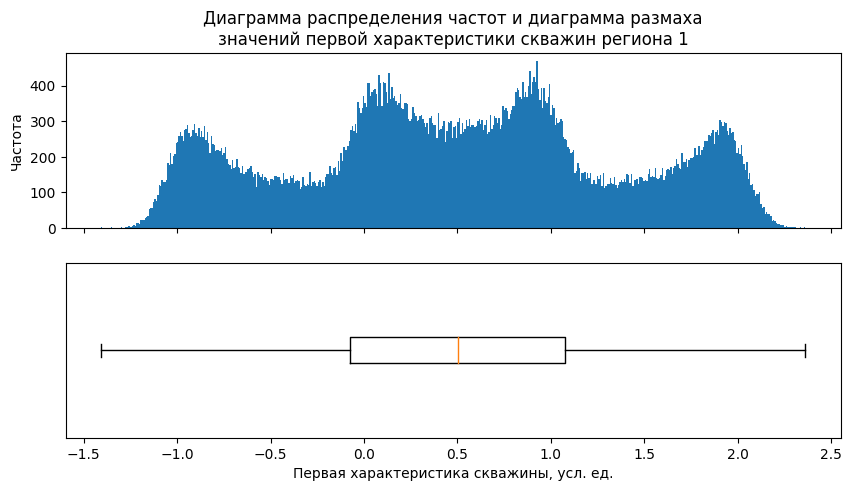

```python
graph(data_0['f0'], 'первой характеристики скважин',
      1, 'Первая характеристика скважины, усл. ед.')
```

- Значения определены для всех записей.
- Для 99 980 записей встречается 99 980 различных уникальных значений.
- Минимальное значение — (−1,408605), максимальное значение — 2,362331.
- Медиана — 0,5, среднее арифметическое — 0,5.
- Распределение мультимодальное, симметричное. Имеет четыре выраженных пика.
- Половина всех значений лежит в пределах от −0,07 до 1,07.
- Практически все значения лежат в пределах от −1,22 до 2,22.

#### Регион 2

```python
descriptive_statistics(data_1['f0'], 'Первая характеристика скважины, усл. ед.')
```

|  | Первая характеристика скважины, усл. ед. |
| --- | --- |
| кол-во значений | 99992 |
| кол-во уникальных | 99992 |
| мин. | -31.609576 |
| -1.5IQR | -21.226042 |
| 25 % | -6.3 |
| мода | [-31.609576019167687, -27.829616136400016, -26... |
| медиана | 1.15 |
| среднее ариф. | 1.14 |
| 75 % | 8.62 |
| +1.5IQR | 23.532422 |
| макс. | 29.421755 |
| размах | 61.031331 |
| межквартильный размах | 14.919488 |

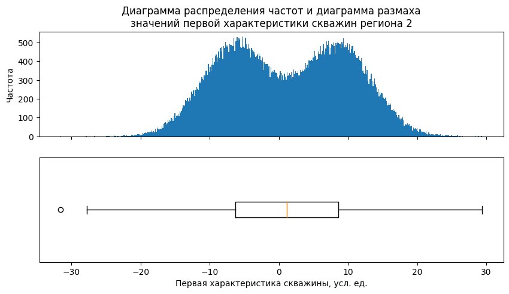

```python
graph(data_1['f0'], 'первой характеристики скважин',
      2, 'Первая характеристика скважины, усл. ед.')
```

- Значения определены для всех записей.
- Для 99 992 записей встречается 99 992 различных уникальных значения.
- Минимальное значение — (−31,609576), максимальное значение — 29,421755.
- Медиана — 1,15, среднее арифметическое — 1,14.
- Распределение бимодальное, симметричное.
- Половина всех значений лежит в пределах от −6,3 до 8,62.
- Практически все значения лежат в пределах от −21,23 до 23,53.

#### Регион 3

```python
descriptive_statistics(data_2['f0'], 'Первая характеристика скважины, усл. ед.')
```

|  | Первая характеристика скважины, усл. ед. |
| --- | --- |
| кол-во значений | 99992 |
| кол-во уникальных | 99992 |
| мин. | -8.760004 |
| -1.5IQR | -3.471743 |
| 25 % | -1.16 |
| мода | [-8.760003624213763, -7.450587110708628, -7.18... |
| медиана | 0.01 |
| среднее ариф. | 0.0 |
| 75 % | 1.16 |
| +1.5IQR | 3.490566 |
| макс. | 7.238262 |
| размах | 15.998266 |
| межквартильный размах | 2.320769 |

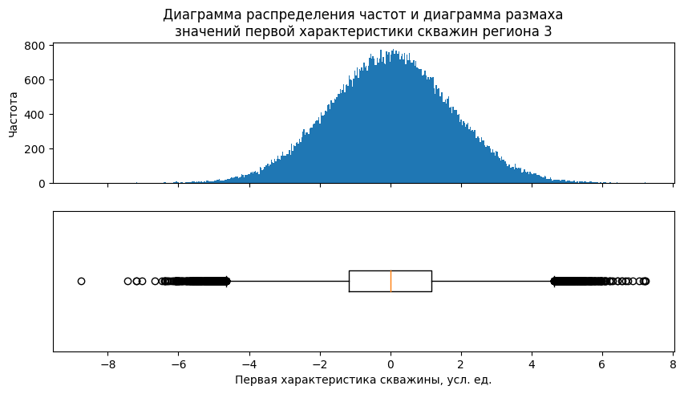

```python
graph(data_2['f0'], 'первой характеристики скважин',
      3, 'Первая характеристика скважины, усл. ед.')
```

- Значения определены для всех записей.
- Для 99 992 записей встречается 99 992 различных уникальных значения.
- Минимальное значение — (−8,760004), максимальное значение — 7,238262.
- Медиана — 0,01, среднее арифметическое — 0.
- Распределение унимодальное, симметричное.
- Половина всех значений лежит в пределах от −1,16 до 1,16.
- Практически все значения лежат в пределах от −3,47 до 3,49.

### Вторая характеристика скважины

#### Регион 1

```python
descriptive_statistics(data_0['f1'], 'Вторая характеристика скважины, усл. ед.')
```

|  | Вторая характеристика скважины, усл. ед. |
| --- | --- |
| кол-во значений | 99980 |
| кол-во уникальных | 99980 |
| мин. | -0.848218 |
| -1.5IQR | -1.102021 |
| 25 % | -0.2 |
| мода | [-0.8482184970082173, -0.8449079224879839, -0.... |
| медиана | 0.25 |
| среднее ариф. | 0.25 |
| 75 % | 0.7 |
| +1.5IQR | 1.602526 |
| макс. | 1.343769 |
| размах | 2.191988 |
| межквартильный размах | 0.901516 |

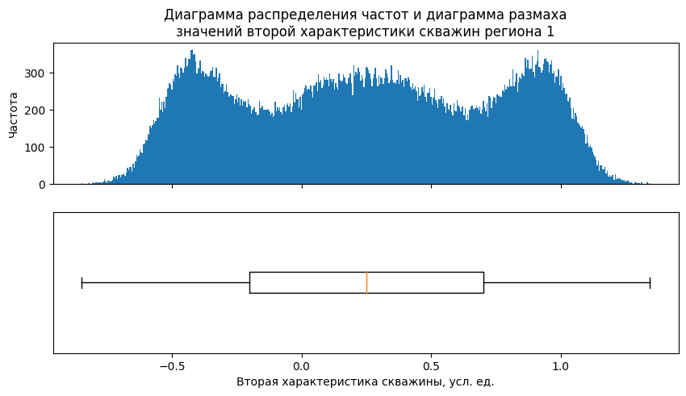

```python
graph(data_0['f1'], 'второй характеристики скважин',
      1, 'Вторая характеристика скважины, усл. ед.')
```

- Значения определены для всех записей.
- Для 99 980 записей встречается 99 980 различных уникальных значений.
- Минимальное значение — (−0,848218), максимальное значение — 1,343769.
- Медиана — 0,25, среднее арифметическое — 0,25.
- Распределение мультимодальное, симметричное. Имеет три выраженных пика.
- Половина всех значений лежит в пределах от −0,2 до 0,7.
- Практически все значения лежат в пределах от −1,1 до 1,6.

#### Регион 2

```python
descriptive_statistics(data_1['f1'], 'Вторая характеристика скважины, усл. ед.')
```

|  | Вторая характеристика скважины, усл. ед. |
| --- | --- |
| кол-во значений | 99992 |
| кол-во уникальных | 99992 |
| мин. | -26.358598 |
| -1.5IQR | -15.215927 |
| 25 % | -8.27 |
| мода | [-26.358598008345872, -25.389622416296945, -25... |
| медиана | -4.81 |
| среднее ариф. | -4.8 |
| 75 % | -1.33 |
| +1.5IQR | 5.589916 |
| макс. | 18.734063 |
| размах | 45.092661 |
| межквартильный размах | 6.935281 |

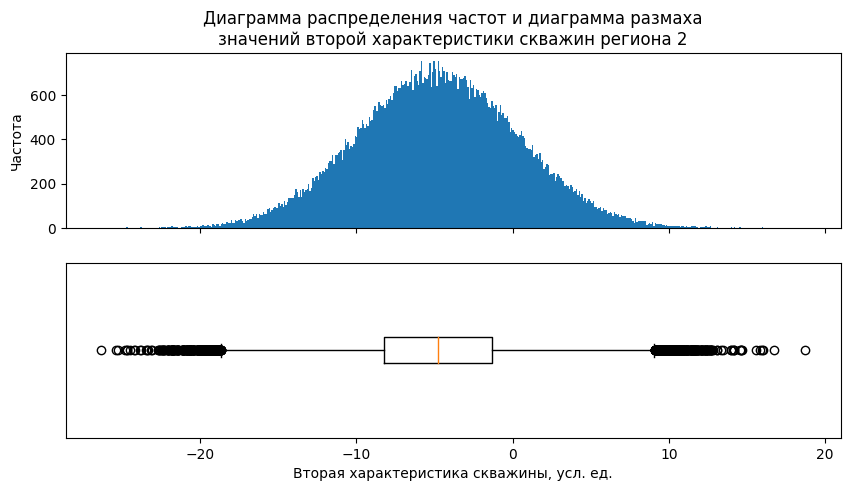

```python
graph(data_1['f1'], 'второй характеристики скважин',
      2, 'Вторая характеристика скважины, усл. ед.')
```

- Значения определены для всех записей.
- Для 99 992 записей встречается 99 992 различных уникальных значения.
- Минимальное значение — (−26,358598), максимальное значение — 18,734063.
- Медиана — (−4,81), среднее арифметическое — (−4,8).
- Распределение унимодальное, симметричное.
- Половина всех значений лежит в пределах от −8,27 до −1,33.
- Практически все значения лежат в пределах от −15,22 до 5,59.

#### Регион 3

```python
descriptive_statistics(data_2['f1'], 'Вторая характеристика скважины, усл. ед.')
```

|  | Вторая характеристика скважины, усл. ед. |
| --- | --- |
| кол-во значений | 99992 |
| кол-во уникальных | 99992 |
| мин. | -7.08402 |
| -1.5IQR | -3.517198 |
| 25 % | -1.17 |
| мода | [-7.084019760867246, -6.748356769522671, -6.73... |
| медиана | -0.01 |
| среднее ариф. | -0.0 |
| 75 % | 1.16 |
| +1.5IQR | 3.498038 |
| макс. | 7.844801 |
| размах | 14.928821 |
| межквартильный размах | 2.338412 |

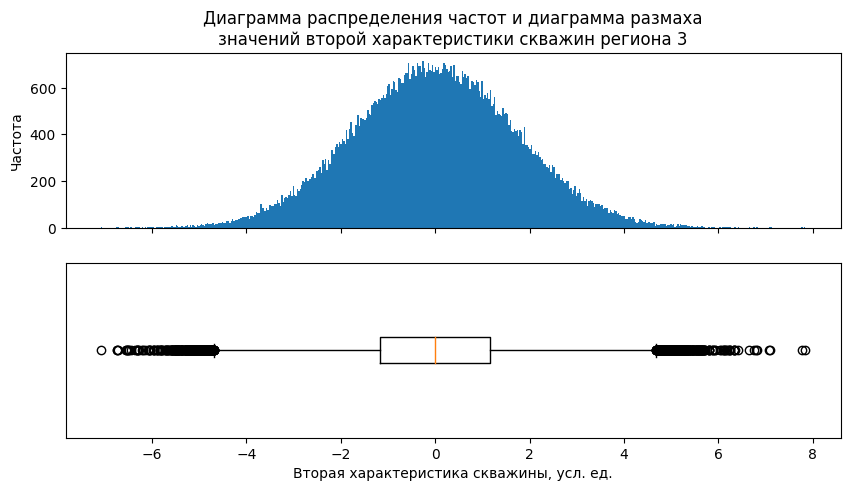

```python
graph(data_2['f1'], 'второй характеристики скважин',
      3, 'Вторая характеристика скважины, усл. ед.')
```

- Значения определены для всех записей.
- Для 99 992 записей встречается 99 992 различных уникальных значения.
- Минимальное значение — (−7,08402), максимальное значение — 7,844801.
- Медиана — (−0,01), среднее арифметическое — 0.
- Распределение унимодальное, симметричное.
- Половина всех значений лежит в пределах от −1,17 до 1,16.
- Практически все значения лежат в пределах от −3,52 до 3,50.

### Третья характеристика скважины

#### Регион 1

```python
descriptive_statistics(data_0['f2'], 'Третья характеристика скважины, усл. ед.')
```

|  | Третья характеристика скважины, усл. ед. |
| --- | --- |
| кол-во значений | 99980 |
| кол-во уникальных | 99980 |
| мин. | -12.088328 |
| -1.5IQR | -4.124307 |
| 25 % | 0.29 |
| мода | [-12.08832811806336, -10.138341352347217, -10.... |
| медиана | 2.52 |
| среднее ариф. | 2.5 |
| 75 % | 4.71 |
| +1.5IQR | 9.156316 |
| макс. | 16.00379 |
| размах | 28.092118 |
| межквартильный размах | 4.426874 |

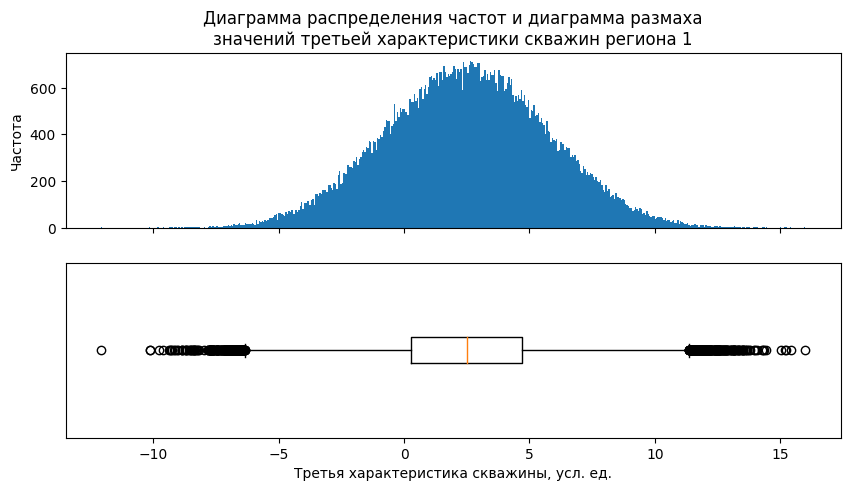

```python
graph(data_0['f2'], 'третьей характеристики скважин',
      1, 'Третья характеристика скважины, усл. ед.')
```

- Значения определены для всех записей.
- Для 99 980 записей встречается 99 980 различных уникальных значений.
- Минимальное значение — (−12,088328), максимальное значение — 16,00379.
- Медиана — 2,52, среднее арифметическое — 2,5.
- Распределение унимодальное, симметричное.
- Половина всех значений лежит в пределах от 0,29 до 4,71.
- Практически все значения лежат в пределах от −4,12 до 9,16.

#### Регион 2

```python
descriptive_statistics(data_1['f2'], 'Третья характеристика скважины, усл. ед.')
```

|  | Третья характеристика скважины, усл. ед. |
| --- | --- |
| кол-во значений | 99992 |
| кол-во уникальных | 99992 |
| мин. | -0.018144 |
| -1.5IQR | -2.48835 |
| 25 % | 1.0 |
| мода | [-0.0181440867134202, -0.0178866789857535, -0.... |
| медиана | 2.01 |
| среднее ариф. | 2.49 |
| 75 % | 4.0 |
| +1.5IQR | 6.5113 |
| макс. | 5.019721 |
| размах | 5.037865 |
| межквартильный размах | 2.999883 |

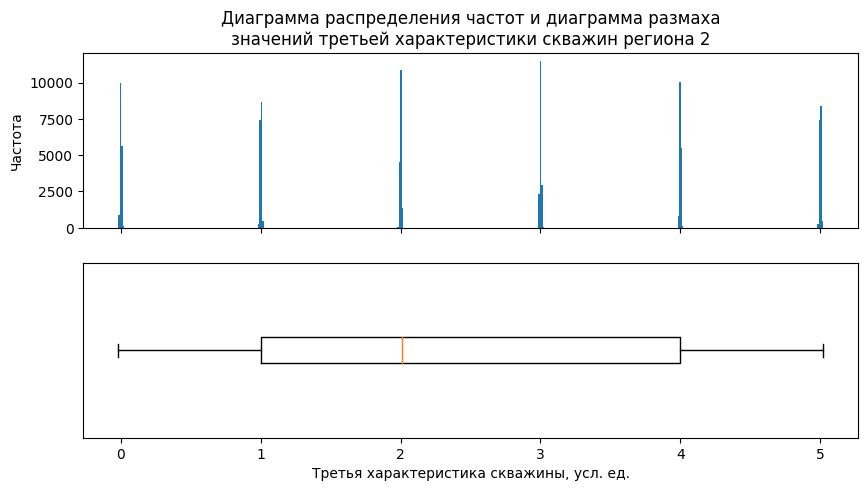

```python
graph(data_1['f2'], 'третьей характеристики скважин',
      2, 'Третья характеристика скважины, усл. ед.')
```

- Значения определены для всех записей.
- Для 99 992 записей встречается 99 992 различных уникальных значения.
- Минимальное значение — (−0,018144), максимальное значение — 5,019721.
- Медиана — 2,01, среднее арифметическое — 2,49.
- Распределение мультимодальное, несимметричное.
- Половина всех значений лежит в пределах от 1 до 4.
- Практически все значения лежат в пределах от −2,49 до 6,51.
- Распределение значений имеет шесть ярко выраженных узких пика. Значения распределены в равной мере относительно чисел 0, 1, 2, 3, 4, 5. Такая группировка всех непрерывных значений признака вокруг шести значений может свидетельствовать больше о категориальном характере признака, нежели о количественном.

#### Регион 3

```python
descriptive_statistics(data_2['f2'], 'Третья характеристика скважины, усл. ед.')
```

|  | Третья характеристика скважины, усл. ед. |
| --- | --- |
| кол-во значений | 99992 |
| кол-во уникальных | 99992 |
| мин. | -11.970335 |
| -1.5IQR | -4.608354 |
| 25 % | 0.13 |
| мода | [-11.97033454147699, -11.611690484056377, -11.... |
| медиана | 2.48 |
| среднее ариф. | 2.5 |
| 75 % | 4.86 |
| +1.5IQR | 9.576826 |
| макс. | 16.739402 |
| размах | 28.709737 |
| межквартильный размах | 4.728393 |

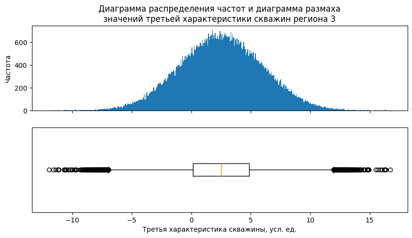

```python
graph(data_2['f2'], 'третьей характеристики скважин',
      3, 'Третья характеристика скважины, усл. ед.')
```

- Значения определены для всех записей.
- Для 99 992 записей встречается 99 992 различных уникальных значения.
- Минимальное значение — (−11,970335), максимальное значение — 16,739402.
- Медиана — 2,48, среднее арифметическое — 2,5.
- Распределение унимодальное, симметричное.
- Половина всех значений лежит в пределах от 0,13 до 4,86.
- Практически все значения лежат в пределах от −4,61 до 9,58.

### Объём запасов нефти в скважине

#### Регион 1

```python
descriptive_statistics(data_0['product'],
                       'Объём запасов нефти в скважине, тыс. баррелей')
```

|  | Объём запасов нефти в скважине, тыс. баррелей |
| --- | --- |
| кол-во значений | 99980 |
| кол-во уникальных | 99980 |
| мин. | 0.0 |
| -1.5IQR | -16.253435 |
| 25 % | 56.5 |
| мода | [0.0, 0.0040215231561772, 0.0061136363115587, ... |
| медиана | 91.85 |
| среднее ариф. | 92.5 |
| 75 % | 128.56 |
| +1.5IQR | 199.949291 |
| макс. | 185.364347 |
| размах | 185.364347 |
| межквартильный размах | 72.067575 |

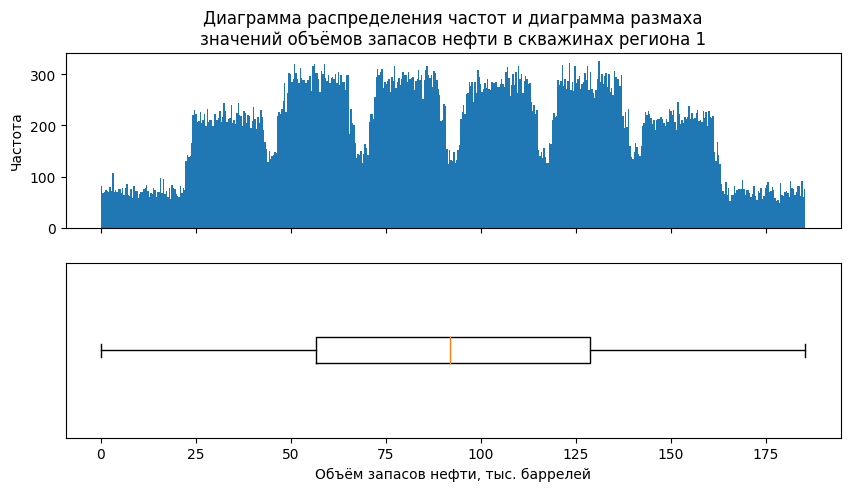

```python
graph(data_0['product'], 'объёмов запасов нефти в скважинах',
      1, 'Объём запасов нефти, тыс. баррелей')
```

- Значения определены для всех записей.
- Для 99 980 записей встречается 99 980 различных уникальных значений.
- Минимальное значение — 0, максимальное значение — 185,364347 тыс. баррелей.
- Медиана — 91,85 тыс. баррелей, среднее арифметическое — 92,5 тыс. баррелей.
- Распределение мультимодальное, симметричное, носит сложный характер.
- Половина всех значений лежит в пределах от 56,5 до 128,56 тыс. баррелей.
- Все значения образуют восемь групп, внутри каждой значения распределены трапециевидно.

#### Регион 2

```python
descriptive_statistics(data_1['product'],
                       'Объём запасов нефти в скважине, тыс. баррелей')
```

|  | Объём запасов нефти в скважине, тыс. баррелей |
| --- | --- |
| кол-во значений | 99992 |
| кол-во уникальных | 12 |
| мин. | 0.0 |
| -1.5IQR | -64.20405 |
| 25 % | 26.95 |
| мода | [53.90652206307938] |
| медиана | 57.09 |
| среднее ариф. | 68.82 |
| 75 % | 107.81 |
| +1.5IQR | 178.375299 |
| макс. | 137.945408 |
| размах | 137.945408 |
| межквартильный размах | 80.859783 |

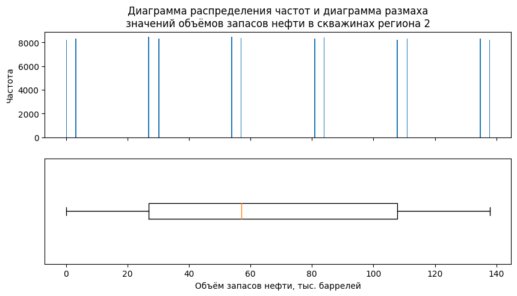

```python
graph(data_1['product'], 'объёмов запасов нефти в скважинах',
      2, 'Объём запасов нефти, тыс. баррелей')
```

- Значения определены для всех записей.
- Для 99 992 записей встречается 12 различных уникальных значений.
- Минимальное значение — 0, максимальное значение — 137,945408 тыс. баррелей.
- Медиана — 57,09 тыс. баррелей.
- Распределение дискретное.
- Каждое из двенадцати значений встречается в наборе данных примерно одинаковое число раз.

#### Регион 3

```python
descriptive_statistics(data_2['product'],
                       'Объём запасов нефти в скважине, тыс. баррелей')
```

|  | Объём запасов нефти в скважине, тыс. баррелей |
| --- | --- |
| кол-во значений | 99992 |
| кол-во уникальных | 99992 |
| мин. | 0.0 |
| -1.5IQR | -11.777628 |
| 25 % | 59.45 |
| мода | [0.0, 0.0046060000398026, 0.0092041119595402, ... |
| медиана | 94.93 |
| среднее ариф. | 95.0 |
| 75 % | 130.59 |
| +1.5IQR | 201.627681 |
| макс. | 190.029838 |
| размах | 190.029838 |
| межквартильный размах | 71.135103 |

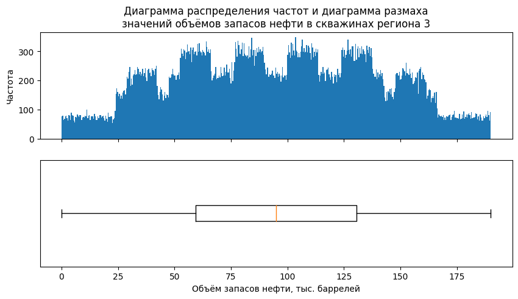

```python
graph(data_2['product'], 'объёмов запасов нефти в скважинах',
      3, 'Объём запасов нефти, тыс. баррелей')
```

- Значения определены для всех записей.
- Для 99 992 записей встречается 99 992 различных уникальных значения.
- Минимальное значение — 0, максимальное значение — 190,029838 тыс. баррелей.
- Медиана — 94,93 тыс. баррелей, среднее арифметическое — 95 тыс. баррелей.
- Распределение мультимодальное, симметричное, носит сложный характер.
- Половина всех значений лежит в пределах от 59,45 до 130,59 тыс. баррелей.
- Все значения образуют восемь групп, внутри каждой значения распределены трапециевидно.

**Промежуточный вывод**

Хотя данные являются синтетическими, однако они должны отражать физическую природу изучаемых явлений. Если физическая природа одинаковая, то распределения одного признака должны быть близкими по формам и характеристикам. Кроме того, важно также, чтобы один и тот же признак измерялся в одной шкале: категориальной или количественной. Тем не менее, если признак по своей природе измеряется в количественной шкале, при помощи полуколичественных измерений возможно получить дискретный набор значений измеряемой величины. Такие измерения позволяют ответить на вопрос: больше или меньше измеряемая величина по сравнению с установленным значением.

## Построение моделей

### Подготовка данных для обучения

Значения признака `id` встречаются в наборах данных по одному разу, в каждом из них все значения признака являются уникальными. Признак является категориальным и может быть заменён без потери смысла на любую последовательность значений, например, на значения индексов строк.  
Эти значения не являются важными для обучения модели, более того, будет ошибочным использовать их для обучения.

Удалим признак `id` из наборов данных.

```python
data_name = []
feature_names = []

for name in data_dict:
    data_dict[name].drop(['id'], axis=1, inplace=True)
    data_name.append(name)
    feature_names.append(data_dict[name].columns.sort_values().tolist())

pd.DataFrame(pd.Series(feature_names, index=data_name),
             columns=['Уникальные наименования признаков'])
```

|  | Уникальные наименования признаков |
| --- | --- |
| Регион 1 | [f0, f1, f2, product] |
| Регион 2 | [f0, f1, f2, product] |
| Регион 3 | [f0, f1, f2, product] |

### Разделение данных на выборки

В каждом наборе данных выделим целевой признак `product`.

```python
features_0 = data_0.drop(['product'], axis=1)
target_0 = data_0['product']

features_1 = data_1.drop(['product'], axis=1)
target_1 = data_1['product']

features_2 = data_2.drop(['product'], axis=1)
target_2 = data_2['product']
```

Согласно условиям задачи, три четверти данных — это исторические данные, с помощью которых можно обучить модели. Остальная четверть данных — локации в регионах, в которых потенциально можно вести бурение и пробурить поисково-разведочные скважины.

Поскольку по условию задачи для этих локаций уже известны значения объёмов запасов, данные об этих локациях возможно использовать для валидации и оценки качества обученных моделей.

Конечно, в условиях реальной геологоразведки значений объёмов запасов в каждой локации у исследователя не будет. Поэтому именно в таких случаях будет важно применять прогнозы обученных моделей и выполнять оценку с использованием полученных прогнозов.

Разделим данные на тренировочную и валидационную выборки в отношении 3 : 1.

Посмотрим, какие выборки получились после разделения.

- Данные региона 1

```python
features_0_train, features_0_valid, target_0_train, target_0_valid = \
    train_test_split(features_0, target_0, test_size=0.25,
                     random_state=RANDOM_STATE)
```

```python
features_0_train.shape
```

```
(74985, 3)
```

```python
features_0_valid.shape
```

```
(24995, 3)
```

- Данные региона 2

```python
features_1_train, features_1_valid, target_1_train, target_1_valid = \
    train_test_split(features_1, target_1, test_size=0.25,
                     random_state=RANDOM_STATE)
```

```python
features_1_train.shape
```

```
(74994, 3)
```

```python
features_1_valid.shape
```

```
(24998, 3)
```

- Данные региона 3

```python
features_2_train, features_2_valid, target_2_train, target_2_valid = train_test_split(
    features_2, target_2, test_size=0.25, random_state=RANDOM_STATE)
```

```python
features_2_train.shape
```

```
(74994, 3)
```

```python
features_2_valid.shape
```

```
(24998, 3)
```

### Обучение моделей

Поскольку целевой признак `product` — количественный (непрерывный), следовательно, необходимо решить задачу регрессии.

Для обучения модели подходит только модель линейной регрессии (остальные модели недостаточно интерпретируемые).

```python
model_0 = LinearRegression(n_jobs=-1)
model_0.fit(features_0_train, target_0_train)
predictions_0_valid = model_0.predict(features_0_valid)

model_1 = LinearRegression(n_jobs=-1)
model_1.fit(features_1_train, target_1_train)
predictions_1_valid = model_1.predict(features_1_valid)

model_2 = LinearRegression(n_jobs=-1)
model_2.fit(features_2_train, target_2_train)
predictions_2_valid = model_2.predict(features_2_valid)
```

### Оценка моделей

Рассчитаем значения среднего объёма запаса поисково-разведочных скважин в каждом регионе по значениям, предсказанным моделями.

Оценку качества обученных моделей проведём, рассчитав значение стандартного отклонения (RMSE).

```python
target_valid = [target_0_valid, target_1_valid, target_2_valid]
predictions_valid = [predictions_0_valid,
                     predictions_1_valid,
                     predictions_2_valid]

rmse = []
predicted_mean = []

for i in range(len(predictions_valid)):
    rmse.append((mean_squared_error(target_valid[i], predictions_valid[i],
                                    squared=False)).round(2))
    predicted_mean.append(predictions_valid[i].mean().round(2))

pd.DataFrame({'Средний объём запаса скважин, тыс. баррелей': predicted_mean,
              'Стандартное отклонение, тыс. баррелей': rmse},
             index=['Регион 1', 'Регион 2', 'Регион 3'])
```

|  | Средний объём запаса скважин, тыс. баррелей | Стандартное отклонение, тыс. баррелей |
| --- | --- | --- |
| Регион 1 | 92.57 | 37.65 |
| Регион 2 | 69.01 | 0.89 |
| Регион 3 | 94.83 | 39.86 |

В регионах 1 и 3 средний объём прогнозируемых запасов находится на уровне 92,57 и 94,83 тыс. баррелей, что близко к средним значениям 92,5 и 95 тыс. баррелей, соответственно. В регионе 2 средний объём прогнозируемых запасов гораздо ниже — на уровне 69 тыс. баррелей и тоже близок к среднему значению 68,82 тыс. баррелей.

## Решение коммерческой задачи

Для решения задачи введём некоторые константы.

```python
# Бюджет на бурение поисково-разведочных скважин в регионе (руб.):
BUDGET = 1e+10

# Цена одного барреля нефти (руб.):
BARREL_PRICE = 450

# Стоимость единицы продукции (руб.):
PRODUCT_PRICE = BARREL_PRICE * 1e+3

# Количество скважин в регионе для исследования:
N_WELLS = 500

# Количество лучших для разработки скважин
# (с максимальным содержанием нефти):
N_BEST_WELLS = 200

# Стоимость бурения одной поисково-разведочной скважины (руб.):
WELL_COST = BUDGET / N_BEST_WELLS
```

Сформируем наборы данных с информацией об объёмах запасов: реальном и спрогнозированном моделью — для каждой скважины.

```python
product_set_0 = pd.DataFrame({'target_valid': target_0_valid.tolist(),
                              'predictions_valid': predictions_0_valid})

product_set_1 = pd.DataFrame({'target_valid': target_1_valid.tolist(),
                              'predictions_valid': predictions_1_valid})

product_set_2 = pd.DataFrame({'target_valid': target_2_valid.tolist(),
                              'predictions_valid': predictions_2_valid})
```

### Минимальный объём запасов нефти в скважине

Оценим минимальным объём запасов нефти в пробуренной скважине, необходимый для безубыточной её разработки. Оценку выполним по формуле:

$Минимальный\ объём\ запасов = \frac{Стоимость\ бурения\ одной\ скважины}{Стоимость\ единицы\ продукции}$

```python
pd.DataFrame({'В регионе 1': target_0_valid.mean().round(2),
              'В регионе 2': target_1_valid.mean().round(2),
              'В регионе 3': target_2_valid.mean().round(2),
              'Минимальный': round(WELL_COST / PRODUCT_PRICE, 2)},
             index = ['Объём запасов нефти в скважине, тыс. баррелей'])
```

|  | В регионе 1 | В регионе 2 | В регионе 3 | Минимальный |
| --- | --- | --- | --- | --- |
| Объём запасов нефти в скважине, тыс. баррелей | 92.33 | 69.01 | 94.78 | 111.11 |

Объём запасов нефти в скважине должен быть не менее 111,12 тыс. баррелей, чтобы её разработка была безубыточной. Средний объём запасов нефти в скважинах регионов 1 и 3 на 15–17 % ниже, а в cкважинах региона 2 — на 38 % ниже требуемого минимального объёма. Следовательно, в процессе выбора скважин для разработки нельзя доверять случаю и выбирать их наугад.

### Максимальная прибыль в регионе

Наиболее выгодная ситуация для нефтедобывающей компании — обнаружить в регионе 200 локаций с максимально возможным значением объёма запаса нефти для данного региона. Тогда и прибыль, получаемая при добыче из таких скважин, будет максимальной в данном регионе

Оценим объём нефти в тех скважинах, которые модель обозначила как содержащие максимально возможные запасы. Оценим объём нефти, который действительно можно добыть из 200 скважин с максимальным значением объёмов запасов. Рассчитаем предельно высокую прибыль, которую возможно получить при нефтедобыче в каждом регионе.

```python
def max_income(product_set, region):
    '''
    Функция для расчёта максимально достижимой прибыли в регионе.

    Принимает набор данных с информацией об объёмах запасов:
    реальном и спрогнозированном моделью, а также название региона.
    Возвращает датафрейм со значениями максимального предсказанного
    и максимального реального объёмов запасов нефти в регионе и
    максимально достижимым значением прибыли.
    '''

    # Отбор 200 локаций с максимальным предсказанным объёмом запасов нефти.
    predicted_product = \
        product_set['predictions_valid'].sort_values().tail(N_BEST_WELLS)

    # Предсказанный суммарный объём запасов нефти в отобранных 200 локациях.
    max_predicted_product = predicted_product.sum().round(0)

    # Отбор 200 локаций с максимальным реальным объёмом запасов нефти.
    real_product = product_set['target_valid'].sort_values().tail(N_BEST_WELLS)

    # Реальный суммарный объём запасов нефти в отобранных 200 локациях.
    max_product = real_product.sum().round(0)

    # Максимальная прибыль, которую можно получить,
    # разрабатывая отобранные 200 локации.
    max_income = ((real_product.sum() * PRODUCT_PRICE - BUDGET) / 1e+9).round(2)

    result = pd.DataFrame({
        'Макс. предсказанный объём, тыс. баррелей': max_predicted_product,
        'Макс. объём, тыс. баррелей': max_product,
        'Макс. прибыль, млрд руб.': max_income},
                          index = [region])

    return result
```

```python
product_list = {'Регион 1': product_set_0,
                'Регион 2': product_set_1,
                'Регион 3': product_set_2}
df = pd.DataFrame()

for product_set in product_list:
    df = pd.concat([df, max_income(product_list[product_set], product_set)])

df
```

|  | Макс. предсказанный объём, тыс. баррелей | Макс. объём, тыс. баррелей | Макс. прибыль, млрд руб. |
| --- | --- | --- | --- |
| Регион 1 | 31086.0 | 36668.0 | 6.50 |
| Регион 2 | 27751.0 | 27589.0 | 2.42 |
| Регион 3 | 29471.0 | 37583.0 | 6.91 |

### Средняя прибыль в регионе

С учётом того, что поиск локаций — явление случайное, вероятность найти 200 локаций с максимально возможным объёмом запаса нефти стремится к нулю.

Поэтому важным является оценка именно среднего значения объёма запасов нефти в 200 разведанных скважинах с учётом случайного их выбора. Также средней будет и оценка получаемой прибыли.

Для того чтобы снизить потенциальный риск, связанный с бурением убыточных скважин, необходимо провести бурение в 500 локациях региона и из 500 пробуренных поисково-разведочных скважин выбрать 200 с наибольшими объёмами запасов. Выбранные 200 скважин затем подвернуть дальнейшей разработке и обустройству.

Моделирование ситуации поиска 500 локаций для бурения, последующего отбора 200 скважин с наибольшими объёмами запасов и оценки среднего значения объёма запаса 200 скважин проведём с использованием метода Монте-Карло. Число формируемых подвыборок установим на уровне 1000. Для каждого региона выборкой будет служить четверть исходного набора данных (примерно 25 000 наблюдений) — те значения, которые предварительно были сохранены в переменные `target_n_valid` и `features_n_valid`.

Введём функцию для расчёта значений прибыли, получаемой при разработке 200 скважин с наибольшими значениями объёмов запасов нефти из 500 скважин, отбираемых на каждой итерации.

Прибыль рассчитаем по формуле:

$Прибыль = Суммарный\ объём\ запасов\ 200\ скважин * Стоимость\ продукта - Бюджет$

```python
def income(product_set):
    '''
    Функция для расчёта прибыли.

    Принимает датафрейм с информацией об объёмах запасов:
    реальном и спрогнозированном моделью.
    Возвращает датафрейм из 200 записей со значениями прибыли,
    рассчитанной по объёмам запасов: реальном и спрогнозированном моделью,
    в 500 скважинах, отобранных методом Монте-Карло за 1000 итераций.
    '''

    N_ITER = 1000
    STATE = np.random.RandomState(1)

    real_income = []
    estimated_income = []

    for _ in range(N_ITER):

        # Случайный выбор 500 локаций региона для бурения
        # поисково-разведочных скважин и последующий отбор 200 скважин
        # с максимальными объёмами запасов.
        subsample = product_set.sample(
            N_WELLS, replace=True, random_state=STATE).sort_values(
                by='predictions_valid').tail(N_BEST_WELLS)

        # Прибыль, рассчитанная по реальным объёмам запасов нефти
        # в 200 скважинах, выбранных моделью.
        real_income.append(
            subsample['target_valid'].sum() * PRODUCT_PRICE - BUDGET)

        # Прибыль, рассчитанная по спрогнозированным объёмам
        # запасов нефти 200 скважин, выбранных моделью.
        estimated_income.append(
            subsample['predictions_valid'].sum() * PRODUCT_PRICE - BUDGET)

    result = pd.DataFrame({'real_income': real_income,
                           'estimated_income': estimated_income})

    return result
```

```python
result_0 = income(product_set_0)
result_1 = income(product_set_1)
result_2 = income(product_set_2)
```

Рассчитаем среднее значение прибыли, интервал значений (правую и левую границы интервала), в который в 95 случаях из 100 попадает значение прибыли, и риск убытка. Риск убытка определяется как доля отрицательных значений прибыли среди всех значений полученного распределения. Значение риска выражается в процентах.

```python
def kde_graph(result, region):
    '''
    График ядерной оценки плотности распределения прибыли
    с указанным средним значением прибыли и границами интервала
    значений прибыли, в который попадают 95 случаев из 100.

    Принимает датафрейм со значением реальной и спрогнозированной прибыли
    и название региона.
    '''

    label = [f'{region}', 'Среднее', '2,5 %-ная граница', '97,5 %-ная граница']

    plt.figure(figsize=(10, 4))
    plt.title('График ядерной оценки плотности распределения' +
              '\nприбыли, рассчитанной по реальным объёмам запасов нефти' +
              '\nв 200 скважинах, выбранных моделью')
    sns.kdeplot(result['real_income'], fill=True)
    plt.axvline(x=result['real_income'].mean(), color='r')
    plt.axvline(x=result['real_income'].quantile(.025),
                color='r', linestyle='--')
    plt.axvline(x=result['real_income'].quantile(.975),
                color='r', linestyle='--')
    plt.xlim(-0.8*10**9, 1.9*10**9)
    plt.xlabel('Прибыль, руб.')
    plt.ylabel('Плотность распределения')
    plt.legend(label)
    plt.show()
```

```python
results = [result_0, result_1, result_2]

mean_real_income = []
mean_estimated_income = []
left_limit = []
right_limit = []
loss_real_risk = []
loss_estimated_risk = []

for result in results:

    # Среднее значение прибыли, рассчитанной по реальным объёмам запасов.
    mean_real_income.append((result['real_income'].mean() / 1e+6).round(0))

    # Среднее значение прибыли, рассчитанной по спрогнозированным объёмам запасов.
    mean_estimated_income.append(
        (result['estimated_income'].mean() / 1e+6).round(0))

    # Значение левой границы интервала прибыли, в который попадают 95 случаев из 100.
    left_limit.append((result['real_income'].quantile(.025) / 1e+6).round(0))

    # Значение правой границы интервала прибыли, в который попадают 95 случаев из 100.
    right_limit.append((result['real_income'].quantile(.975) / 1e+6).round(0))

    # Риск убытка, рассчитанный по реальным объёмам запасов нефти.
    loss_real_risk.append((result['real_income'] < 0).mean() * 100)

    # Риск убытка, рассчитанный по спрогнозированным объёмам запасов нефти.
    loss_estimated_risk.append((result['estimated_income'] < 0).mean() * 100)
```

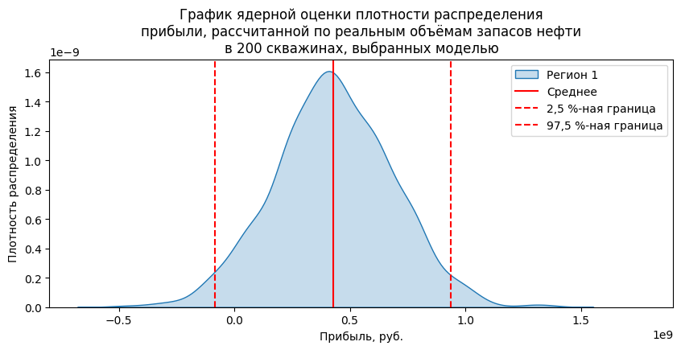

```python
kde_graph(result_0, 'Регион 1')
```

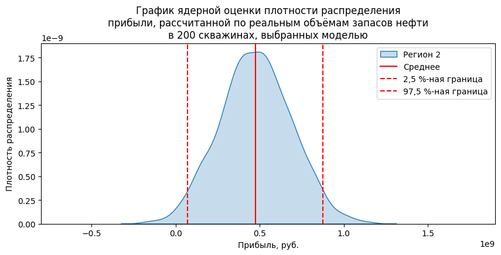

```python
kde_graph(result_1, 'Регион 2')
```

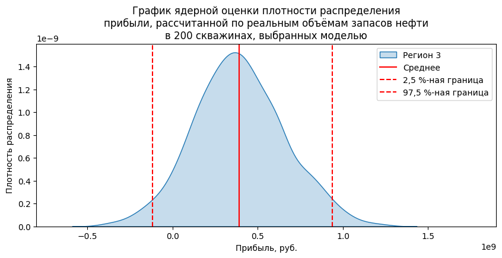

```python
kde_graph(result_2, 'Регион 3')
```

```python
pd.DataFrame({'Левая граница, млн руб.': left_limit,
              'Средняя прибыль, млн руб.': mean_real_income,
              'Правая граница, млн руб.': right_limit,
              'Риск убытков, %': loss_real_risk},
             index=['Регион 1', 'Регион 2', 'Регион 3'])
```

|  | Левая граница, млн руб. | Средняя прибыль, млн руб. | Правая граница, млн руб. | Риск убытков, % |
| --- | --- | --- | --- | --- |
| Регион 1 | -84.0 | 428.0 | 936.0 | 4.7 |
| Регион 2 | 70.0 | 476.0 | 875.0 | 0.9 |
| Регион 3 | -119.0 | 391.0 | 939.0 | 6.2 |

Среди всех регионов наибольший риск убытков наблюдается в регионе 3: в 6,2 % случаев разработка 200 новых скважин будет убыточной. В регионе 1 тоже наблюдается высокий риск убытков: в 4,7 % случаев разработка 200 скважин будет убыточной. Только в регионе 2 риск убытков ниже 2,5 %: в 0,9 % случаев разработка 200 скважин не принесёт дохода.

Такое распределение значений риска убытков коррелирует со средним значением прибыли от разработки 200 скважин в регионе. Минимальное значение средней прибыли достигается в регионе 3 — 391 млн руб. Немного большее значение — в регионе 1 и составляет 428 млн руб. Максимальное значение средней прибыли достигается в регионе 2 — 476 млн руб.

При разработке 200 скважин в регионе 2 в 95 случаях из 100 разработка точно принесёт прибыль, значение которой будет лежать в диапазоне 70–875 млн руб. Разброс значений прибыли в регионах 1 и 3 гораздо шире. Так при рассмотрении 95 случаев из 100 максимально возможная прибыль находится на уровне 936–939 млн руб., а вот минимальная граница находится в области отрицательных значений, и разработка в этих случаях будет убыточной.

Средняя прибыль, которую можно получить при разработке 200 скважин в регионе 2 составляет 20 % от максимально возможной прибыли, средняя прибыль в регионах 1 и 3 — лишь 7 % и 6 %, соответственно. Такая картина может быть следствием формы распределения значений объёма запаса нефти в регионах: в регионах 1 и 3 распределение непрерывное, а в регионе 2 практически дискретное.

```python
pd.DataFrame({'Средняя оценённая прибыль, млн руб.': mean_estimated_income,
              'Средняя прибыль, млн руб.': mean_real_income,
              'Оценённый риск убытков, %': loss_estimated_risk,
              'Риск убытков, %': loss_real_risk,},
             index=['Регион 1', 'Регион 2', 'Регион 3'])
```

|  | Средняя оценённая прибыль, млн руб. | Средняя прибыль, млн руб. | Оценённый риск убытков, % | Риск убытков, % |
| --- | --- | --- | --- | --- |
| Регион 1 | 366.0 | 428.0 | 0.0 | 4.7 |
| Регион 2 | 474.0 | 476.0 | 1.0 | 0.9 |
| Регион 3 | 247.0 | 391.0 | 1.0 | 6.2 |

Полезно сравнить значения средней прибыли с её оценкой, полученной из прогнозов модели. Для регионов 1 и 3 модель сильно занижает среднее значение прибыли — это является следствием больших ошибок предсказаний (высокое значение стандартного отклонения). Рассчитанное значение риска по предсказанным значениям свидетельствует о низком риске (не более 1 % случаев выбора скважин для бурения является убыточными), что является неправдой и может стать неприятным сюрпризом для нефтедобывающей компании.

А вот оценённое по прогнозам модели значение средней прибыли для региона 2 близко к значению средней прибыли, которая может быть физически получена. Риск оценён в этом случае на том же уровне — 1 % случаев выбора 200 скважин из 500 может быть убыточным.

## Общий вывод

1. По данным каждого региона были обучены модели линейной регрессии. Качество моделей было оценено расчётом значения стандартного отклонения. Наилучшей предсказательной способностью обладает модель, обученная на данных региона 2.
2. Методом Монте-Карло была смоделирована процедура выбора 500 локаций для бурения поисково-разведочных скважин в каждом регионе и отбора 200 локаций с наибольшим значением объёма запаса нефти для последующей разработки и обустройства.
3. Среднее значение прибыли, которую можно получить при разработке 200 скважин,
- в регионе 1 составляет 428 млн руб.,
- в регионе 2 составляет 476 млн руб.,
- в регионе 3 составляет 391 млн руб.
4. 95 значений прибыли из 100 попадают в интервал
- от −84 до 936 млн руб. — в регионе 1,
- от 70 до 875 млн руб. — в регионе 2,
- от −119 до 939 млн руб. — в регионе 3.
5. Риск убытков при разработке 200 скважин
- в регионе 1 составляет 4,7 %,
- в регионе 2 составляет 0,9 %,
- в регионе 3 составляет 6,2 %.
6. Для разработки 200 скважин рекомендуется нефтеносный регион 2: риск убытков от разработки составляет менее 2,5 %, среднее значение возможной прибыли имеет максимальное значение.